# Income Analysis Using GSS Data: Estimating Ability Bias

Author

Wade Zhou

Published

August 24, 2025

```r
# Setup

knitr::opts_chunk$set(echo = TRUE, message = FALSE, warning = FALSE, fig.align = "center")
library(tidyverse)
library(scales)
options(pillar.sigfig = 3)
```

## Project Overview

This analysis uses General Social Survey (GSS) data to examine how cognitive ability affects income across different education levels. The GSS includes a vocabulary test (wordsum) that serves as a proxy for academic ability, allowing us to estimate “ability bias”–the extent to which observed education premiums reflect underlying cognitive differences rather than purely educational effects.

This analysis has obvious limitations: we cannot cleanly separate ability from education, lack data on fields of study or institutional quality, and assume wordsum adequately captures cognitive ability, etc. We also make simplifying assumptions about GSS survey design.

We use specific ability percentile cutoffs (24th, 41st, 73rd, 82nd) that correspond to college completion rates from Bryan Caplan’s research. This allows results to feed into financial models calculating the return on college investment for students of different ability levels.

## Setup: Packages

```r
# CRAN packages

cran_pkgs <- c("tidyverse","scales","knitr","clipr")
need <- cran_pkgs[!vapply(cran_pkgs, requireNamespace, logical(1), quietly=TRUE)]
if (length(need)) install.packages(need)
lapply(cran_pkgs, library, character.only=TRUE)

# gssr via r-universe (preferred) or fallback to GitHub if needed

if (!requireNamespace("gssr", quietly=TRUE)) {
  # Try r-universe first (fast, no build tools typically needed)
  old_repos <- getOption("repos")
  options(repos = c('https://kjhealy.r-universe.dev', old_repos))
  try(install.packages("gssr"), silent = TRUE)
  options(repos = old_repos)
}
if (!requireNamespace("gssr", quietly=TRUE)) {
  # Fallback: GitHub
  if (!requireNamespace("remotes", quietly = TRUE)) install.packages("remotes")
  remotes::install_github("kjhealy/gssr")
}
library(gssr)
```

## Data & Methodology

The analysis uses GSS data from 2016–2022, focusing on workforce participants. The wordsum variable (vocabulary test score) serves as a proxy for cognitive ability, while `income16` provides family income data in ranges that we convert to numeric midpoints. We inflation-adjust to 2022 dollars.

### Load and Filter GSS Data

```r
# Load GSS data

data(gss_all)

# Filter for workforce participants with complete data
gss1a <- gss_all %>%
  select(year, wordsum, age, educ, degree, rincome, income16, wrkstat, wtssps) %>%
  filter(year >= 2016,
                wrkstat %in% c(1, 2, 3, 4),  # In workforce
                !is.na(wordsum), !is.na(income16),
                educ >= 0, degree >= 0)

# Convert wordsum to percentiles (unweighted)

gss1a <- gss1a %>%
  mutate(wordsum_percentile = percent_rank(wordsum) * 100)

head(gss1a)
```

```
# A tibble: 6 × 10
  year      wordsum   age      educ     degree  rincome  income16 wrkstat wtssps
  <dbl+lbl> <dbl+lbl> <dbl+lb> <dbl+lb> <dbl+l> <dbl+lb> <dbl+lb> <dbl+l> <dbl+>
1 2016      8         47       16 [4 y… 3 [bac… 12 [$25… 26 [$17… 1 [wor… 0.727
2 2016      5         61       12 [12t… 1 [hig… 12 [$25… 19 [$50… 1 [wor… 0.338
3 2016      5         43       12 [12t… 1 [hig…  9 [$10… 26 [$17… 2 [wor… 1.25
4 2016      6         50       14 [2 y… 1 [hig… 12 [$25… 26 [$17… 1 [wor… 1.42
5 2016      6         45       12 [12t… 1 [hig… 11 [$20… 20 [$60… 1 [wor… 1.21
6 2016      4         32       12 [12t… 1 [hig…  4 [$4,…  8 [$8,… 2 [wor… 1.81
# ℹ 1 more variable: wordsum_percentile <dbl>
```

### Income Range Conversion

```r
# Map income16 categories to numeric midpoints (see GSS variable docs)

get_midpoint <- function(x) {
  if (is.na(x) || is.null(x)) return(NA_real_)
  x <- suppressWarnings(as.numeric(as.character(x)))
  if (is.na(x)) return(NA_real_)
  if (x %in% c(-100, -98, -97, -90)) return(NA_real_)  # NA / DK / SKIP / REFUSED
  if (x == 1)  return(500)     # UNDER $1,000
  if (x == 26) return(185000)  # $170,000 OR OVER (chosen anchor)
  if (x >= 2 && x <= 25) {
    range <- switch(as.character(x),
      "2"=c(1000,2999),   "3"=c(3000,3999),   "4"=c(4000,4999),   "5"=c(5000,5999),
      "6"=c(6000,6999),   "7"=c(7000,7999),   "8"=c(8000,9999),   "9"=c(10000,12499),
      "10"=c(12500,14999),"11"=c(15000,17499),"12"=c(17500,19999),"13"=c(20000,22499),
      "14"=c(22500,24999),"15"=c(25000,29999),"16"=c(30000,34999),"17"=c(35000,39999),
      "18"=c(40000,49999),"19"=c(50000,59999),"20"=c(60000,74999),"21"=c(75000,89999),
      "22"=c(90000,109999),"23"=c(110000,129999),"24"=c(130000,149999),"25"=c(150000,169999)
    )
    return(mean(range))
  }
  NA_real_
}

gss1a$income16_numeric <- vapply(gss1a$income16, get_midpoint, numeric(1))

gss1a
```

```
# A tibble: 4,631 × 11
   year      wordsum   age     educ     degree  rincome  income16 wrkstat wtssps
   <dbl+lbl> <dbl+lbl> <dbl+l> <dbl+lb> <dbl+l> <dbl+lb> <dbl+lb> <dbl+l> <dbl+>
 1 2016      8         47      16 [4 y… 3 [bac… 12 [$25… 26 [$17… 1 [wor… 0.727
 2 2016      5         61      12 [12t… 1 [hig… 12 [$25… 19 [$50… 1 [wor… 0.338
 3 2016      5         43      12 [12t… 1 [hig…  9 [$10… 26 [$17… 2 [wor… 1.25
 4 2016      6         50      14 [2 y… 1 [hig… 12 [$25… 26 [$17… 1 [wor… 1.42
 5 2016      6         45      12 [12t… 1 [hig… 11 [$20… 20 [$60… 1 [wor… 1.21
 6 2016      4         32      12 [12t… 1 [hig…  4 [$4,…  8 [$8,… 2 [wor… 1.81
 7 2016      4         76      10 [10t… 0 [les… 11 [$20… 18 [$40… 3 [wit… 0.394
 8 2016      5         31      18 [6 y… 4 [gra… 12 [$25… 17 [$35… 1 [wor… 0.242
 9 2016      7         43      13 [1 y… 1 [hig… 12 [$25… 15 [$25… 1 [wor… 0.403
10 2016      9         58      12 [12t… 1 [hig… 12 [$25… 22 [$90… 1 [wor… 0.461
# ℹ 4,621 more rows
# ℹ 2 more variables: wordsum_percentile <dbl>, income16_numeric <dbl>
```

### Inflation Adjustment

```r
# Adjust to 2022 dollars, using BLS CPIAUCSL

inflation_lookup <- tibble(
  year = c(2016, 2018, 2021, 2022),
  cpi  = c(81.2,  84.6,  94.0, 100.0)
)

gss1a <- gss1a %>%
  left_join(inflation_lookup, by = "year") %>%
  mutate(income16_numeric_22 = income16_numeric / cpi * 100)

head(gss1a)
```

```
# A tibble: 6 × 13
  year      wordsum   age      educ     degree  rincome  income16 wrkstat wtssps
  <dbl+lbl> <dbl+lbl> <dbl+lb> <dbl+lb> <dbl+l> <dbl+lb> <dbl+lb> <dbl+l> <dbl+>
1 2016      8         47       16 [4 y… 3 [bac… 12 [$25… 26 [$17… 1 [wor… 0.727
2 2016      5         61       12 [12t… 1 [hig… 12 [$25… 19 [$50… 1 [wor… 0.338
3 2016      5         43       12 [12t… 1 [hig…  9 [$10… 26 [$17… 2 [wor… 1.25
4 2016      6         50       14 [2 y… 1 [hig… 12 [$25… 26 [$17… 1 [wor… 1.42
5 2016      6         45       12 [12t… 1 [hig… 11 [$20… 20 [$60… 1 [wor… 1.21
6 2016      4         32       12 [12t… 1 [hig…  4 [$4,…  8 [$8,… 2 [wor… 1.81
# ℹ 4 more variables: wordsum_percentile <dbl>, income16_numeric <dbl>,
#   cpi <dbl>, income16_numeric_22 <dbl>
```

### Education Categories

```r
# Parsing gss variables

combine_education <- function(educ, degree) {
  case_when(
    educ %in% c(-99, -98, -97) | degree %in% c(-99, -98, -97) ~ NA_character_,
    educ < 12 ~ "Less than High School",
    educ == 12 & degree == 1 ~ "High School Graduate",
    educ > 12 & degree == 1 ~ "Some College (No Degree)",
    degree == 2 ~ "Associate/Junior College",
    degree == 3 ~ "Bachelor's",
    degree == 4 ~ "Graduate Degree",
    TRUE ~ NA_character_
  )
}

gss1a_clean <- gss1a %>%
  mutate(
    edu_combined = combine_education(educ, degree),
    income16_numeric = as.numeric(income16_numeric),
    wordsum_percentile = as.numeric(wordsum_percentile),
    age = as.numeric(age)
  ) %>%
  filter(!is.na(edu_combined))

# Show weighted sample sizes by education
gss1a_clean %>%
  count(edu_combined, wt = wtssps) %>%
  arrange(desc(n), digits = 0,
               format.args = list(big.mark = ","))
```

```
# A tibble: 6 × 2
  edu_combined                 n
  <chr>                    <dbl>
1 High School Graduate     1174.
2 Bachelor's               1044.
3 Some College (No Degree)  970.
4 Graduate Degree           613.
5 Associate/Junior College  425.
6 Less than High School     378.
```

## Analysis Results

### Regression Model

```r
# Basic regression model

model <- stats::lm(
  income16_numeric_22 ~ wordsum_percentile * edu_combined + age + I(age^2),
  data = gss1a_clean,
  weights = wtssps
)
summary(model)
```

```
Call:
stats::lm(formula = income16_numeric_22 ~ wordsum_percentile *
    edu_combined + age + I(age^2), data = gss1a_clean, weights = wtssps)

Weighted Residuals:
    Min      1Q  Median      3Q     Max
-243124  -35214  -13875   21163  341955

Coefficients:
                                                          Estimate Std. Error
(Intercept)                                             -19825.262  10262.008
wordsum_percentile                                         176.659    122.301
edu_combinedBachelor's                                   24333.915   7128.659
edu_combinedGraduate Degree                              64448.406   8677.222
edu_combinedHigh School Graduate                        -10494.834   6410.783
edu_combinedLess than High School                       -38471.283   7303.617
edu_combinedSome College (No Degree)                     -8263.857   6900.468
age                                                       4284.825    409.458
I(age^2)                                                   -40.272      4.559
wordsum_percentile:edu_combinedBachelor's                   23.062    141.670
wordsum_percentile:edu_combinedGraduate Degree            -382.050    157.098
wordsum_percentile:edu_combinedHigh School Graduate       -102.048    143.827
wordsum_percentile:edu_combinedLess than High School        84.209    180.682
wordsum_percentile:edu_combinedSome College (No Degree)    134.668    145.769
                                                        t value Pr(>|t|)
(Intercept)                                              -1.932 0.053457 .
wordsum_percentile                                        1.444 0.148705
edu_combinedBachelor's                                    3.414 0.000649 ***
edu_combinedGraduate Degree                               7.427 1.41e-13 ***
edu_combinedHigh School Graduate                         -1.637 0.101714
edu_combinedLess than High School                        -5.267 1.47e-07 ***
edu_combinedSome College (No Degree)                     -1.198 0.231167
age                                                      10.465  < 2e-16 ***
I(age^2)                                                 -8.833  < 2e-16 ***
wordsum_percentile:edu_combinedBachelor's                 0.163 0.870696
wordsum_percentile:edu_combinedGraduate Degree           -2.432 0.015072 *
wordsum_percentile:edu_combinedHigh School Graduate      -0.710 0.478052
wordsum_percentile:edu_combinedLess than High School      0.466 0.641203
wordsum_percentile:edu_combinedSome College (No Degree)   0.924 0.355634
---
Signif. codes:  0 '***' 0.001 '**' 0.01 '*' 0.05 '.' 0.1 ' ' 1

Residual standard error: 53240 on 3284 degrees of freedom
  (1269 observations deleted due to missingness)
Multiple R-squared:  0.2431,    Adjusted R-squared:  0.2401
F-statistic: 81.14 on 13 and 3284 DF,  p-value: < 2.2e-16
```

### Predicted Income by Ability and Education

```r
# Predictions at selected percentiles and age 42 (age of median US worker)

inference <- expand.grid(
  wordsum_percentile = c(25, 50, 75),
  edu_combined = c("High School Graduate", "Some College (No Degree)", "Bachelor's"),
  age = 42
)

inference$predicted_income <- as.numeric(predict(model, newdata = inference))

predicted_values <- inference %>%
  select(-age) %>%
  mutate(predicted_income = dollar(predicted_income)) %>%
  pivot_wider(
    names_from = wordsum_percentile,
    values_from = predicted_income,
    names_prefix = "Ability_"
  ) %>%
  rename(
    `Education Level` = edu_combined,
    `25th Percentile` = Ability_25,
    `50th Percentile` = Ability_50,
    `75th Percentile` = Ability_75
  )

print(predicted_values)
```

```
# A tibble: 3 × 4
  `Education Level`        `25th Percentile` `50th Percentile` `75th Percentile`
  <fct>                    <chr>             <chr>             <chr>
1 High School Graduate     $80,469           $82,334           $84,199
2 Some College (No Degree) $88,617           $96,401           $104,184
3 Bachelor's               $118,425          $123,418          $128,411
```

### Key Findings Visualization

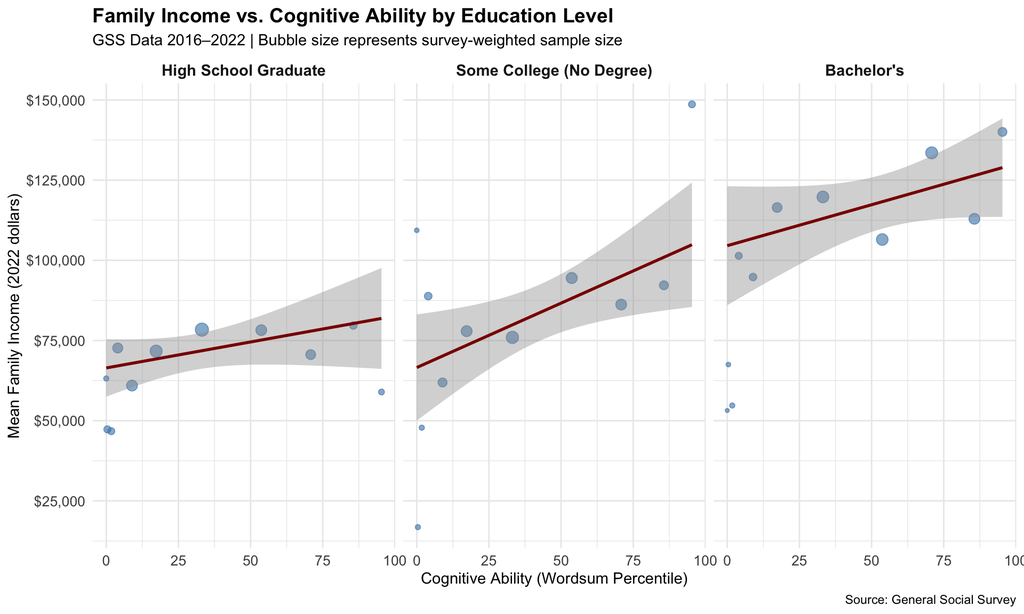

```r
# Wordsum is still correlated with earnings, even controlling for education.
# Interestingly, the slope is highest for people with some college,
# but no degree.

chart_data <- gss1a_clean %>%
  filter(edu_combined %in% c("High School Graduate", "Some College (No Degree)", "Bachelor's")) %>%
  group_by(edu_combined, wordsum_percentile) %>%
  summarise(
    mean_income  = stats::weighted.mean(income16_numeric_22, wtssps, na.rm = TRUE),
    total_weight = sum(wtssps, na.rm = TRUE),
    .groups = "drop"
  ) %>%
  mutate(
    edu_combined = factor(edu_combined,
      levels = c("High School Graduate", "Some College (No Degree)", "Bachelor's")),
    wordsum_percentile = as.numeric(wordsum_percentile)
  ) %>%
  drop_na(mean_income, total_weight, wordsum_percentile)

ggplot(chart_data, aes(x = wordsum_percentile, y = mean_income)) +
  geom_point(aes(size = total_weight), alpha = 0.6, color = "steelblue", na.rm = TRUE) +
  facet_wrap(~edu_combined) +
  stat_smooth(
    aes(weight = total_weight, group = 1),
    method = "lm", formula = y ~ x, se = TRUE, color = "darkred"
  ) +
  scale_y_continuous(labels = dollar_format(), breaks = seq(0, 150000, by = 25000)) +
  scale_size_continuous(range = c(1, 4), guide = "none") +
  labs(
    title = "Family Income vs. Cognitive Ability by Education Level",
    subtitle = "GSS Data 2016–2022 | Bubble size represents survey-weighted sample size",
    x = "Cognitive Ability (Wordsum Percentile)",
    y = "Mean Family Income (2022 dollars)",
    caption = "Source: General Social Survey"
  ) +
  theme_minimal() +
  theme(
    plot.title = element_text(size = 14, face = "bold"),
    strip.text = element_text(size = 11, face = "bold"),
    axis.text = element_text(size = 10)
  )
```

### Income Premiums by Ability Level

```r
# Computes predicted incomes across ability percentiles and education levels,
# then calculates ratios relative to median ability (50th percentile).

# Broader grid to compute ratios
inference_all <- expand.grid(
  wordsum_percentile = c(24, 41, 50, 73, 82),
  edu_combined = unique(gss1a_clean$edu_combined),
  age = 42
)

inference_all$predicted_values <- as.numeric(predict(model, newdata = inference_all))

inference_50 <- filter(inference_all, wordsum_percentile == 50)

df_ratio <- inference_all %>%
  left_join(inference_50, by = "edu_combined", suffix = c("", "_50")) %>%
  mutate(ratio = predicted_values / predicted_values_50)

ratio_export <- df_ratio %>%
  filter(edu_combined %in% c("High School Graduate", "Some College (No Degree)", "Bachelor's")) %>%
  select(wordsum_percentile, edu_combined, predicted_values, ratio)

# Show nicely
ratio_export %>%
  mutate(
    edu_combined = factor(edu_combined,
                         levels = c("High School Graduate",
                                   "Some College (No Degree)",
                                   "Bachelor's")),
    predicted_values = dollar(predicted_values),
    ratio = round(ratio, 2)
  ) %>%
  arrange(edu_combined, wordsum_percentile)
```

```
   wordsum_percentile             edu_combined predicted_values ratio
1                  24     High School Graduate          $80,394  0.98
2                  41     High School Graduate          $81,662  0.99
3                  50     High School Graduate          $82,334  1.00
4                  73     High School Graduate          $84,050  1.02
5                  82     High School Graduate          $84,721  1.03
6                  24 Some College (No Degree)          $88,306  0.92
7                  41 Some College (No Degree)          $93,599  0.97
8                  50 Some College (No Degree)          $96,401  1.00
9                  73 Some College (No Degree)         $103,561  1.07
10                 82 Some College (No Degree)         $106,363  1.10
11                 24               Bachelor's         $118,225  0.96
12                 41               Bachelor's         $121,621  0.99
13                 50               Bachelor's         $123,418  1.00
14                 73               Bachelor's         $128,012  1.04
15                 82               Bachelor's         $129,809  1.05
```

```r
# Also save to CSV
write.csv(ratio_export, "ratio_export.csv", row.names = FALSE)
```

## Supplementary: Predicted Lines by Age

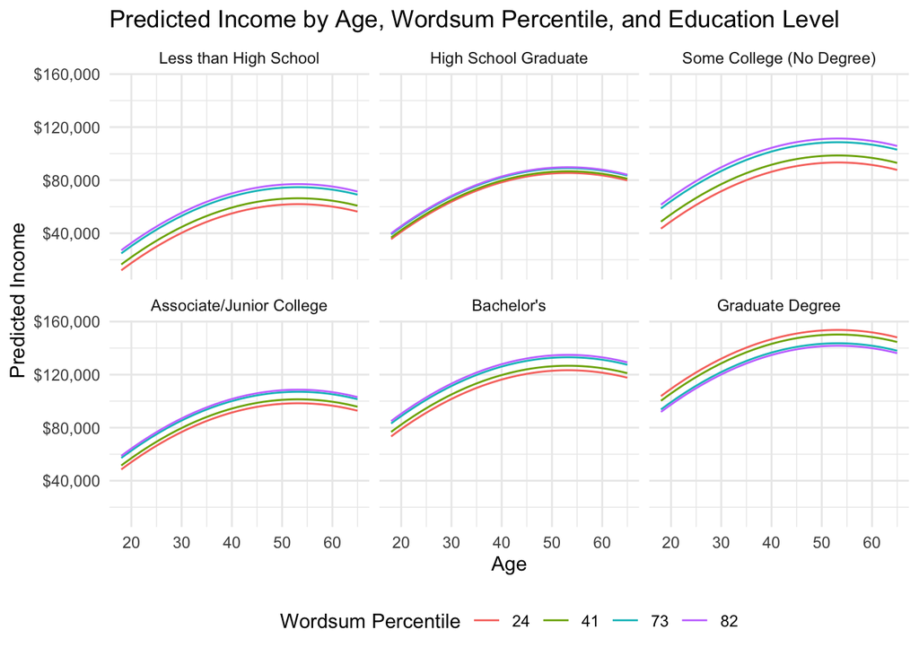

```r
# Build modelled career earnings trajectories for people of different education
# levels and wordsum. Wordsum seems to have very little impact on earnings for
# high school graduates.

if (inherits(model, "lm")) {
  predict_data <- expand_grid(
    age = seq(18, 65, by = 1),
    wordsum_percentile = c(24, 41, 73, 82),
    edu_combined = unique(gss1a_clean$edu_combined)
  )
  predictions <- predict_data %>%
    mutate(
      predicted_income = predict(model, newdata = .),
      edu_combined = factor(edu_combined,
                           levels = c("Less than High School",
                                     "High School Graduate",
                                     "Some College (No Degree)",
                                     "Associate/Junior College",
                                     "Bachelor's",
                                     "Graduate Degree"))
    )

  ggplot(predictions, aes(x = age, y = predicted_income, color = factor(wordsum_percentile))) +
    geom_line() +
    facet_wrap(~edu_combined) +
    scale_y_continuous(labels = dollar_format()) +
    labs(title = "Predicted Income by Age, Wordsum Percentile, and Education Level",
                  x = "Age", y = "Predicted Income", color = "Wordsum Percentile") +
    theme_minimal() +
    theme(legend.position = "bottom")
}
```

## Notes on Weights

Our descriptive statistics and regression models use GSS survey weights (wtssps) to make results representative of the US population. We do not take into account of the GSS’s possibly more complex survey design. This is likely fine for our purposes, but for rigorous inference, consult GSS documentation.